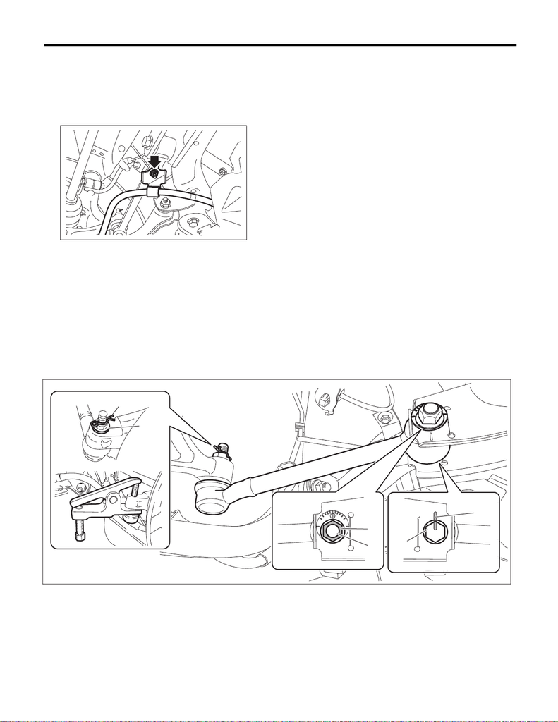

RS-21

Front Lateral Link

REAR SUSPENSION

7. Front Lateral Link

A: REMOVAL

1) Lift up the vehicle, and then remove the rear wheels.

2) Remove the trailing link. <Ref. to RS-16, REMOVAL, Rear Trailing Link.>

3) Remove the nuts, and remove the cable assembly - parking brake.

4) Remove the lateral link assembly - front.

(1) Remove the snap pin (a) and nut (b).

(2) Remove the ball joint from the housing assembly - rear axle.

Preparation tool:

Tie-rod ball joint puller

(3) Scribe alignment marks (c) on the adjusting bolt for lateral link assembly - front and on the rear sub

frame assembly.

(4) Remove the adjusting bolt (d), and remove the lateral link assembly - front.

CAUTION:

When removing the adjusting bolt (d), make sure to fix the bolt head in place when loosening the nut

(e).

RS-00535

RS-00534

(b)

(a)

(e)

(d)

(c)

(d)

[figure not shown]

RS-22

Front Lateral Link

REAR SUSPENSION

B: INSTALLATION

CAUTION:

• For parts which are not reusable, always use new parts.

• Always tighten the bushing in the state where the vehicle is at curb weight and the wheels are in

full contact with the ground.

1) Before installation, inspect the following items and replace any faulty part with a new one.

• Visually check the lateral link assembly - front for damage and deformation.

• Visually check the bushing for abnormal cracks, fatigue or damage.

• Visually check the dust cover on the ball joint for abnormal cracks, fatigue or damage.

2) Install the lateral link assembly - front.

CAUTION:

• When installing the adjusting bolt (d), make sure to fix the bolt head in place and tighten the nut

side (e).

• Align alignment marks (c) on the adjusting bolt for lateral link assembly - front and on the rear sub

frame assembly.

Tightening torque:

Refer to “COMPONENT” of “General Description” for the tightening torque. <Ref. to RS-3, COM-

PONENT, General Description.>

3) Install the nuts, and install the cable assembly - parking brake.

Tightening torque:

18 N·m (1.8 kgf-m, 13.3 ft-lb)

4) Install the trailing link.

Tightening torque:

110 N·m (11.2 kgf-m, 81.1 ft-lb)

5) Install the rear wheels and lower the vehicle.

Tightening torque:

120 N·m (12.2 kgf-m, 88.5 ft-lb)

6) Inspect the wheel alignment and adjust if necessary.

• Inspection: <Ref. to FS-10, INSPECTION, Wheel Alignment.>

• Adjustment: <Ref. to FS-15, ADJUSTMENT, Wheel Alignment.>

CAUTION:

When the wheel alignment has been adjusted, perform “VDC sensor midpoint setting mode” of the

VDC. <Ref. to VDC-16, ADJUSTMENT, VDC Control Module and Hydraulic Control Unit (VDCCM&H/

U).>

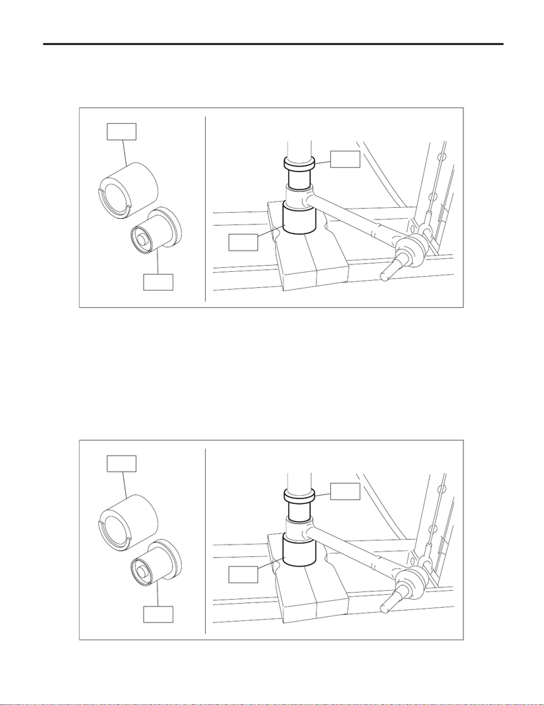

RS-23

Front Lateral Link

REAR SUSPENSION

C: DISASSEMBLY

Using the ST, push out the bushing B - lateral link.

Preparation tool:

ST-A & ST-B: INSTALLER & REMOVER (20299AE000)

D: ASSEMBLY

1) Before assembly, inspect the following items and replace any faulty part with a new one.

• Visually check the lateral link assembly - front for damage and deformation.

• Visually check the bushing for abnormal cracks, fatigue or damage.

• Visually check the dust cover on the ball joint for damage.

2) Using the ST, press-fit the bushing B - lateral link.

CAUTION:

Make sure to press the bushing straight in.

Preparation tool:

ST-A & ST-B: INSTALLER & REMOVER (20299AE000)

RS-00348

ST-A

ST-B

ST-A

ST-B

RS-00348

ST-A

ST-B

ST-A

ST-B